# RaceReport

## Fantasy League Scores

Scores for drivers/constructors in the current year's fantasy league, along with manager/team points, values, and statistics. Note: driver and constructor values are taken as the cost to enter the current race and are updated the week before the race.

## Lineup Scores

Max Verstappen makes it two-from-two in Baku to take the top step once again with a staggering 45 points. In second place, it's star of the week Carlos Sainz with 33 points, ahead of the Mercedes pair. Russell ahead of Antonelli with 30 and 22 points, respectively. Liam Lawson rounds out the top five with 17 points. Down at the bottom of the table, it's championship leader Oscar Piastri, who comes away from Baku with -16 points. He's joined by Alonso with -3, and Stroll with -2. Following them it's Colapinto with 1, and Hadjar and Hulkenberg with 4 points each.

Red Bull take the top step this week, which might be the first time McLaren haven't all season, maybe Canada? The Milton Keynes team come away with 85 points ahead of rivals Mercedes with 67. Williams round out the podium with 46 points. Aston Martin are at the bottom this week with -2, followed by McLaren with 6 and Alpine with 7. A fall from grace for the championship leaders.

Lando Norris retakes the top spot in the championship standings with 544 points, just 1 ahead of his teammate Oscar Piastri with 543. Max creeps a little closer in third place with 455, ahead of George Russell with 395. Lewis Hamilton holds on to fifth place with 283 points. Colapinto remains at the bottom of the table with 4 points behind teammate Gasly with 19. Fernando Alonso is next with 26 points, behind Liam Lawson with 34. Gabriel Bortoleto rounds out the bottom five with 49 points.

McLaren remain at the top with 1370 points, ahead of Ferrari in second with 804. They're in a close fight with Red Bull and Mercedes, with the former in third place with 756. Alpine remain at the bottom with 94 points, behind a close battle with Aston Martin and Kick Sauber with 248 and 257 points.

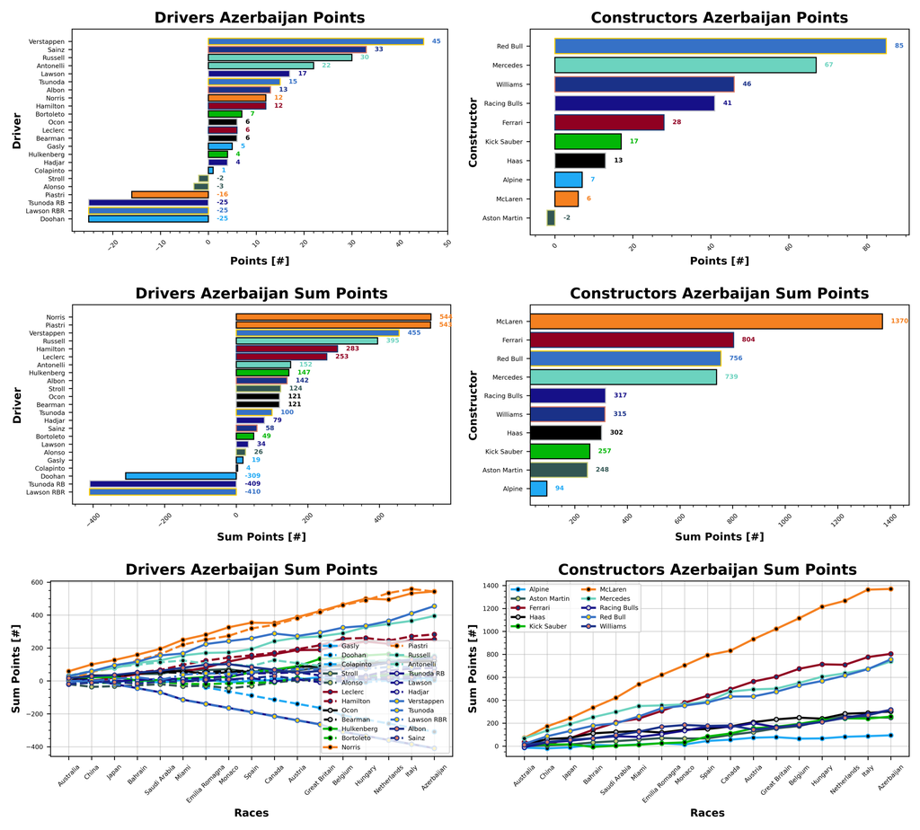

Norris' value continues to take a decline this week, dropping to 31.2. Max Verstappen is in second with an increase to 28.2, followed by Oscar Piastri who remains at 26.7. Leclerc drops to 23.3 this week, ahead of Hamilton at 23.2. Colapinto and Gasly sit at the bottom with a value of 4.5, followed by Sainz with 5.1 and Lawson with 5.3. Bortoleto next at 5.7, and Hadjar with 6.3.

McLaren's value continues to rise to 34.8 this week, ahead of Ferrari at 30.5 and Red Bull at 29.6, all teams increasing. Alpine rise to 7.9, behind Kick Sauber at 10.5 and Racing Bulls at 12.4.

All values are in Million Dollars.

Mr Consistent, George Russell, is now the only driver this year to score positively in every race, the Brit standing in a league of his own at the top. He's followed by Verstappen, Piastri, and Ocon who have all dropped 1 race. Colapinto sits at the bottom, scoring positively in just over a third of the races. He's behind Gasly, Lawson, and Tsunoda who have managed just over half of the races with a positive score.

Red Bull, Mercedes, and McLaren maintain their 100% record this season, with Alpine down at the bottom with 70% of the races scored positively.

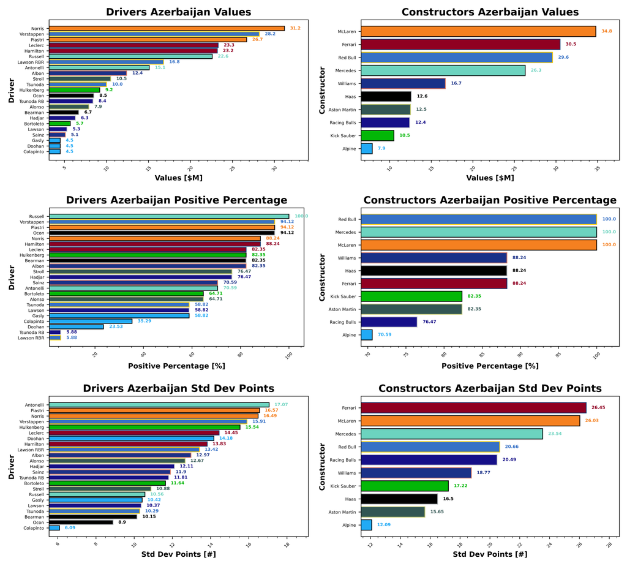

Colapinto remains your most reliable driver of the season, with a standard deviation from his average score of 6.09 points. Ocon, Bearman, Tsunoda, and Lawson are the remaining consistent drivers of the top five. Your least consistent driver of the season is rookie Kimi Antonelli, with a standard deviation of 17.07 points. Alpine are your most consistent team of the season with a standard deviation of 12.09 points, they're followed by Aston Martin and Haas. Your least consistent team is Ferrari with a standard deviation of 26.45 points.

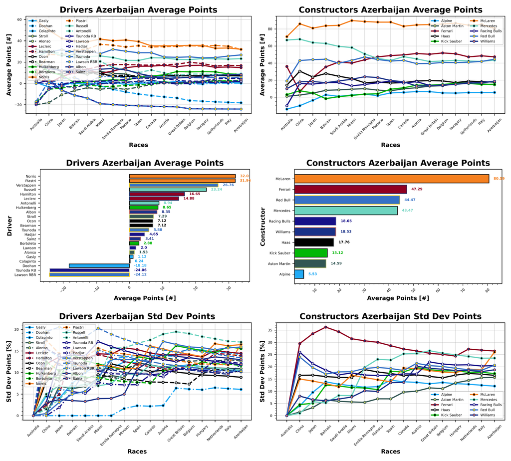

Your driver of the week this week is Carlos Sainz, whose podium has secured him a points per value of 6.47 ppm. Liam Lawson is a distant second with 3.21 ppm, followed by Verstappen with 1.6 ppm and Tsunoda with 1.5 ppm. Kimi Antonelli pips his teammate to fifth with 1.46 ppm. Oscar Piastri was your worst driver of the race this week with -0.6 ppm, behind Alonso with -0.38 ppm and Stroll with -0.19 ppm. Colapinto is next with 0.22 ppm, and Charles Leclerc rounds out the bottom five with 0.26 ppm.

Racing Bulls are your team of the week this week with 3.31 ppm, ahead of Red Bull with 2.87 ppm. Williams are in third with 2.75 ppm. Aston Martin were your worst team of the week with -0.16 ppm, behind McLaren with 0.17 ppm, and Alpine with 0.89 ppm.

ppm = points per million Dollars.

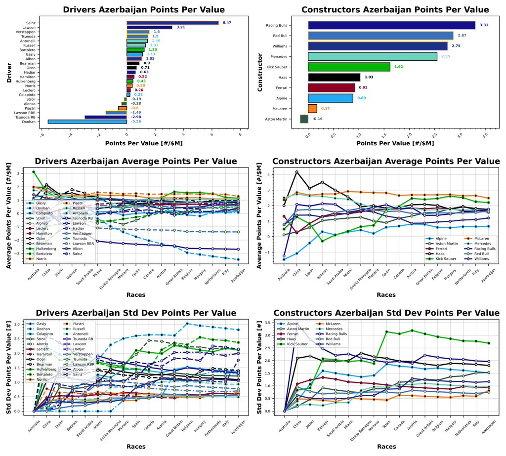

### Manager Scores

In his rookie season, Finn takes the top step this week with Ro@d R@ge bringing home 247 points. Sam is in second with Total F1 Performance and 229 points. Val is a distant third with Its 'odinge' and 147 points, ahead of Madlen with Wet Tyres Are Blue with 136. Chloe rounds out the top five with No Keys - Push To Start with 134 points.

Even in a mixed up week, Valerie still takes the top step of the Golf League this week with What Arrrgh Ya Doohan scoring -34 points. Phil joins them at the bottom with BMW Should Be Here with -25 points, followed by Valerie and Stroll To The 18th with -23 points. Then we have James and Bwoah Schweppes Puma Golf with -1, followed by Stuart with Taylormade To Lose with 3 points.

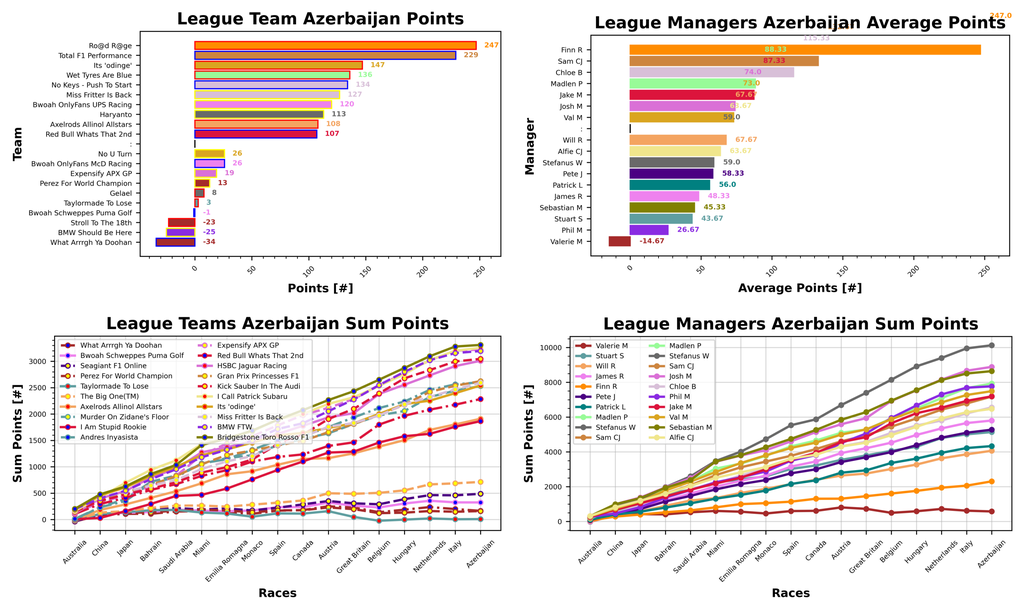

Stefanus and Syahrul hold on to the top step for another week with 3588 points, Patrick and You Hadjar Chance Racing are in second with 3356 points. Stefanus and Haryanto are in third place with 3319, followed by Sebastian and Bridgestone Toro Rosso F1 in fourth with 3311, and Alfie rounds out the top five with I Call Patrick Subaru with 3256 points.

Stuart and Taylormade To Lose hold on to the Golf League with 8 points, followed by Valerie's stable of teams with Perez For World Champion, What Arrrgh Ya Doohan, and Stroll to the 18th with 160, 164, and 254 points each. James and Bwoah Schweppes Puma Golf are in fifth place with 324.

Biggest winners this week are Sam and Finn with their teams Total F1 Performance and Ro@d R@ge jumping 3 places in the standings. Biggest loser this week is Phil with BMW Should Be Here, dropping 3 places.

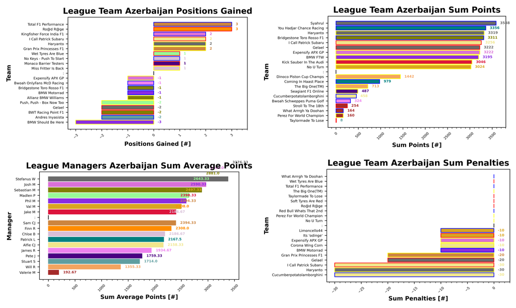

Isack Hadjar remains your most selected driver of the season with 31 appearances this week. He's followed by Oscar Piastri with 22, Nico Hulkenberg with 21, Fernando Alonso with 18, and Carlos Sainz with 17 selections. Yuki Tsunoda and Max Verstappen were your least selected drivers this week with only 2 appearances each. Hamilton and Antonelli are next with only 3, followed by Leclerc and Stroll with 7. Russell makes 8, behind Colapinto, Gasly, Norris, and Ocon with 10.

McLaren remain your most selected team with 20 this week, ahead of Kick Sauber with 17 and Haas with 13. Mercedes were your least selected with 3, behind Williams with 5, and Alpine and Red Bull with 6.

Oscar Piastri remains at the top of the DRS Boost chart with 22 selections ahead of teammate Norris with 5. Leclerc makes it to third with 4. No tokens used this week.

Please note, teams are only checked if their weekly scores do not match a copy-paste team sheet. Teams are checked at the end of the season to ensure accurate statistics.

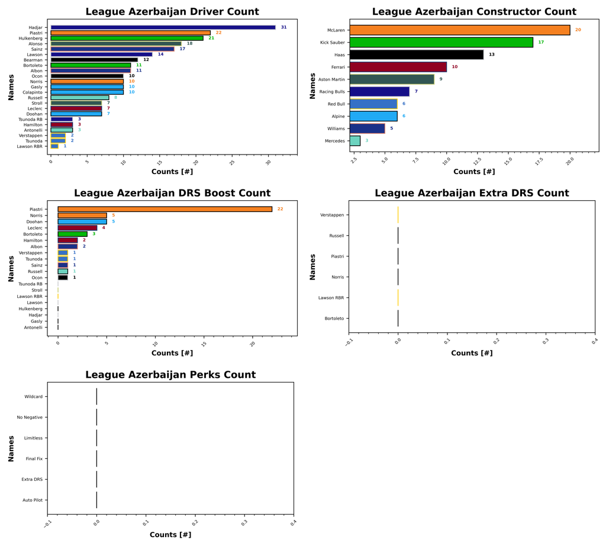

## Prizes

### Championship

| Prize Name | Prize Value | Terms |
| --- | --- | --- |
|  | (%) |  |
| Champion of the World | 20 | Awarded to the top scorer in the league at the end of the season |
| If You're Not First, You're Last | 10 | Awarded to the second place scorer in the league at the end of the season |
| Alpine Podium | 5 | Awarded to the third place scorer in the league at the end of the season |
| Above Par | 20 | Awarded to the lowest scorer in the league at the end of the season, commonly referred to as the Golf League |

### Achievements

| Prize Name | Prize Value | Terms |
| --- | --- | --- |
|  | (%) |  |
| Cost Cappen | 5 | Highest average points per value at the end of the season |
| Sprint King | 5 | Highest score across the sprint races (China, Miami, Belgium, United States, Brazil, Qatar) |
| Flavio Controls Every Millimeter | 5 | Manager wide substitution count, highest wins |
| The Triple Header | 5 | Highest score across the triple header races (Japan, Bahrain, Saudi Arabia, Emilia Romagna, Monaco, Spain, Las Vegas, Qatar, Abu Dhabi) |
| I Forgot I Was Taking Part | 5 | Highest score in the first part of the season |
| Zak's Master Plan | 5 | Lowest score in the second half of the season |
| Mega Driver | 5 | Highest Extra DRS token score |
| The Continental | 5 | Highest score across all 5 continents, Mexico classed as South America for inclusion only (Australia, Canada, Great Britain, Azerbaijan, Mexico) |

### Spot Prizes

| Prize Name | Prize Value | Terms |
| --- | --- | --- |
|  | (%) |  |
| The Ring | 1 | Highest score at the Austrian Grand Prix |
| Bottas Bowling | 1 | Highest score at the Hungarian Grand Prix |
| Daniel's Broken Hand | 1 | Lowest score at the Netherlands Grand Prix |
| The Tifosi | 1 | Lowest score at the Italian Grand Prix |
| Go For The Gap | 1 | Lowest score at the Singapore Grand Prix |

### Spot Prizes

No spot prize this week.

### Cost Cappen

Patrick and You Hadjar Chance Racing are leading the way with a 1.920 ppm, ahead of Stefanus and Syahrul with 1.899 ppm. Alfie and I Call Patrick Subaru are in third place with 1.872 ppm.

### Flavio Controls Every Millimeter

Stefanus leads the way with Gelael and Haryanto sitting on 42 and 41 substitutes each, followed by Josh in third with Kingfisher Force India F1 with 39.

### Mega Driver

Check back later!

### Sprint King

Check back later!

### The Continental

Finn currently leads the way with Ro@d R@ge sitting on 617 points. Sebastian is in second with Bridgestone Toro Rosso F1 and 599 points. Jake and Kick Sauber in the Audi are in third with 576 points.

### The Triple Header

Check back later!

### I Forgot I Was Taking Part

I Forgot I Was Taking Part comes to a close, with Stefanus and Syahrul taking the top step with 3128 points. Haryanto is in second with 2924 points, and Sebastian and Bridgestone Toro Rosso F1 rounds out the podium with 2874 points.

### Zak's Master Plan

Patrick and You Hadjar Chance Racing lead the way with 711 points, ahead of Madlen and Wet Tyres Are Blue with 704, tied with Sam and Total F1 Performance. Finn and Ro@d R@ge are in third with 686 points.

## F1 Predict

Josh took victory this week with 73 points scored, ahead of Phil in second with 71. Stuart came home in third with 48 points, ahead of Val in fourth with 38. Pierce and Matty scored 0.

Phil holds on to the lead with 1028 points, ahead of Stuart with 980. Josh moves up to third with 790, with Val in fourth with 783. Pierce remains on 248 and Matty on 95.

## Next Up

Next up, under the lights in Singapore. F1's original night race. All to play for as we get into the business end of the season.